# Lecture 6 part two

562770bf

2024-12-02

This is the Readme file for the Data Science and HR analytics course, trying out experiments on the code for lecture 6.

So let’s get started.

```r
data <- read.table("/Users/annelies2/Downloads/abortion.dat", skip=1, sep="\t")
names(data) <- c("state","year","pop","y_viol","y_prop","y_murd",
    "a_murd","a_viol","a_prop",'prison','police',
    'ur','inc','pov','afdc','gun','beer')

data <- data[!(data$state%in%c(2,9,12)),]
data <- data[data$year>84 & data$year<98,]
data$pop <- log(data$pop)
t <- data$year - 85
s <- factor(data$state)

controls <- data.frame(data[,c(3,10:17)])
y <- data$y_murd
d <- data$a_murd
summary(orig <- glm(y ~ d + t + s +., data=controls) )$coef['d',]
```

```
##      Estimate    Std. Error       t value      Pr(>|t|)
## -2.098119e-01  4.109177e-02 -5.105936e+00  4.505925e-07
```

```r
dcoef <- summary(orig <- glm(y ~ d + t + s +., data=controls) )$coef['d',][1]
exp(dcoef) - 1
```

```
##   Estimate
## -0.1892633
```

```r
cell <- read.csv("/Users/annelies2/Downloads/us_cellphone.csv")
cellrate <- 5*cell[,2]/(1000*cell[,3])

phone <- cellrate[ t + 1 ]
tech <- summary(glm(y ~ phone + t + s +., data=controls))$coef['phone',]
phonecoef <- tech[1]
exp(phonecoef) - 1
```

```
##   Estimate
## -0.3106956
```

```r
t <- factor(t)
interact <- glm(y ~ d + t + phone*s + .^2, data=controls)
summary(interact)$coef["d",]
```

```
##   Estimate Std. Error    t value   Pr(>|t|)
##  0.2797107  0.1807311  1.5476619  0.1223753
```

```r
library(gamlr)
## refactor state to have NA reference level
sna <- factor(s, levels=c(NA,levels(s)), exclude=NULL)
x <- sparse.model.matrix( ~ t + phone*sna + .^2, data=controls)[,-1]
dim(x)
```

```
## [1] 624 154
```

```r
source("/Users/annelies2/Downloads/orthoML.R")
dreg <- function(x,d){ cv.gamlr(x, d, lmr=1e-5) }

yreg <- function(x,y){ cv.gamlr(x, y, lmr=1e-5) }

resids <- orthoPLTE( x=x, d=d, y=y,
                dreg=dreg, yreg=yreg, nfold=5)
```

```
## fold: 1  2  3  4  5
## gamma (se) = -0.135959 (0.147008)
```

The dreg function uses the gamlr function to create a regularized model that predicts treatment d from features x, with cross-validation for tuning. Similarly, yreg predicts the outcome y from x.

```r
head(resids$dtil)
```

```
## [1]  0.020230375  0.013661466  0.006450831  0.001990802  0.001001104
## [6] -0.012858236
```

```r
head(resids$ytil)
```

```
## [1]  0.04350777 -0.09303663 -0.06367108  0.03695389  0.05499870  0.14479072
```

```r
2*pnorm(-abs(resids$gam)/resids$se) #p-value supports no effect of abortion access on crime
```

```
##      dtil
## 0.3550493
```

The orthoLTE function in the sourced file performs Orthogonal ML. It begins by splitting the data into folds for cross-validation. In each fold, it trains the treatment and outcome models (dreg and yreg) on the training data and predicts the treatment and outcome for the test data. It computes residuals for treatment and outcome (orthogonalizing them) and stores these in dtil and ytil. Finally, it fits a linear model using the residuals to estimate the effect of the treatment on the outcome (gamma) and calculates its standard error.

```r
# Experiment
source("/Users/annelies2/Downloads/orthoML.R")
dreg <- function(x,d){ cv.gamlr(x, d, lmr=1e-5) }

yreg <- function(x,y){ cv.gamlr(x, y, lmr=1e-5) }

resids <- orthoPLTE( x=x, d=d, y=y,
                dreg=dreg, yreg=yreg, nfold=10)  #changing the number of folds
```

```
## fold: 1  2  3  4  5  6  7  8  9  10
## gamma (se) = -0.0131077 (0.0894946)
```

```r
head(resids$dtil)
```

```
## [1]  0.016918614  0.015384458  0.020793929  0.008992571 -0.002802331
## [6] -0.016365503
```

```r
head(resids$ytil)
```

```
## [1]  0.02475353 -0.10814871 -0.08613900 -0.01478113  0.07536597  0.10677337
```

```r
2*pnorm(-abs(resids$gam)/resids$se)
```

```
##      dtil
## 0.8835552
```

```r
library(foreign)

descr <- read.dta("/Users/annelies2/Downloads/oregonhie_descriptive_vars.dta")
prgm <- read.dta("/Users/annelies2/Downloads/oregonhie_stateprograms_vars.dta")
s12 <- read.dta("/Users/annelies2/Downloads/oregonhie_survey12m_vars.dta")

# nicely organized, one row per person
all(s12$person_id == descr$person_id)
```

```
## [1] TRUE
```

```r
all(s12$person_id == prgm$person_id)
```

```
## [1] TRUE
```

```r
P <- descr[,c("person_id","household_id", "numhh_list")]
P$medicaid <- as.numeric(prgm[,"ohp_all_ever_firstn_30sep2009"]=="Enrolled")
P$selected <- as.numeric(descr[,"treatment"]=="Selected")
levels(P$numhh_list) <- c("1","2","3+")

# 12 month is the survey that really matters
# need to control for household size interacted with survey return time
Y <- s12[,c("weight_12m",
    "doc_any_12m","doc_num_mod_12m",
    "er_any_12m","er_num_mod_12m",
    "hosp_any_12m","hosp_num_mod_12m")]
Y$doc_any_12m <- as.numeric(Y$doc_any_12m=="Yes")
Y$er_any_12m <- as.numeric(Y$er_any_12m=="Yes")
Y$hosp_any_12m <- as.numeric(Y$hosp_any_12m=="Yes")

# smk_ever_12m - num19_12m are sources of heterogeneity, plus descr
X <- s12[,121:147]
X$dt_returned <- factor(format(s12$dt_returned_12m, "%Y-%m"))

insurv <- which(s12$sample_12m_resp == "12m mail survey responder")
X <- X[insurv,]
Y <- Y[insurv,]
P <- P[insurv,]

sapply(Y,function(y) sum(is.na(y)))
```

```
##       weight_12m      doc_any_12m  doc_num_mod_12m       er_any_12m
##                0              249              300              227
##   er_num_mod_12m     hosp_any_12m hosp_num_mod_12m
##              260              168              202
```

```r
nomiss <- which( !apply(Y,1, function(y) any(is.na(y))) )
X <- X[nomiss,]
Y <- Y[nomiss,]
P <- P[nomiss,]

# pull out the weights and attach doc_any to P
weights <- Y[,1]
Y <- Y[,-1]

# replace some ridiculous values in survey and drop num19
X$hhsize_12m[X$hhsize_12m>10] <- 10
X$num19_12m <- NULL

# organize to make it pretty for text
P$doc_any_12m <- Y$doc_any_12m # you can explore other responses if you want
P <- P[,c(1,2,6,5,4,3)]
names(P)[6] <- "numhh"

################## basic diffs in mean

head(P)
```

```
##   person_id household_id doc_any_12m selected medicaid numhh
## 1         1       100001           0        1        0     1
## 2         2       100002           0        1        1     1
## 5         5       100005           0        1        0     1
## 6         6       100006           1        1        0     1
## 8         8       102094           0        0        0     2
## 9         9       100009           1        0        0     1
```

```r
dim(P)
```

```
## [1] 23107     6
```

```r
table(P$selected)
```

```
##
##     0     1
## 11629 11478
```

The head command shows the first six rows of the dataset. The dim command shows the dimensions of the P dataset as a numeric vector, where the first number is the number of rows (observations) and the second number is the number of columns (variables). This line creates a frequency table for the selected variable, showing how many individuals were selected versus not selected for treatment.

```r
ybar <- tapply(P$doc_any_12m, P$selected, mean)
( ATE = ybar['1'] - ybar['0'] )
```

```
##          1
## 0.05746606
```

This code calculates the Average Treatment Effect (ATE) of the treatment variable (selected) on the outcome variable (doc_any_12m). Tapply computes the mean of the outcome variable (whether someone visited a doctor in the last year) separately for each value of the treatment variable selected (1 for selected, 0 for not selected). The result is a named vector with the mean for each group. The second line of code calculates the difference in means between the treated group (selected = 1) and the control group (selected = 0). This difference represents the Average Treatment Effect (ATE), which is the causal effect of treatment on the outcome.

```r
#Experiment
# add in column
P$er_any_12m <- Y$er_any_12m
# Calculate the average treatment effect for ER visits
ybar_er <- tapply(P$er_any_12m, P$selected, mean, na.rm = TRUE)  # Set na.rm = TRUE to ignore NAs
ATE_er <- ybar_er['1'] - ybar_er['0']  # Average Treatment Effect

# Output the result
print(ATE_er)
```

```
##            1
## -0.002527142
```

The value -0.002527142 indicates a very small negative effect associated with the treatment. A possible reason for this small (negative) effect could be that people only go to the ER that actually need urgent medical help and randomly becoming health insurance might not have a major impact on the probability that one is seriously injured (Doubt: is this theory likely to be true, since Americans go to the ER as they have to be helped there?).

```r
nsel <- table(P[,c("selected")])
yvar <- tapply(P$doc_any_12m, P$selected, var)
( seATE = sqrt(sum(yvar/nsel)) )
```

```
## [1] 0.006428387
```

```r
ATE + c(-2,2)*seATE
```

```
## [1] 0.04460929 0.07032284
```

This code calculates the standard error and confidence interval for the Average Treatment Effect (ATE) of the treatment on doc_any_12m. Nsel calculates the number of observations in each group (treatment = 1 and control = 0) based on the selected variable. Yvar computes the variance of the outcome variable (doc_any_12m) separately for the treatment and control groups. seATE calculates the standard error of the ATE. The formula sums the variances of the two groups divided by their respective sample sizes, then takes the square root. This accounts for the variability of the outcome within each group and the sample size. Last line calculates a 95% confidence interval for the ATE. It adds and subtracts approximately two standard errors (seATE) from the ATE to provide the interval.

The standard error suggests that the estimate of the ATE is quite precise (small variability). The confidence interval provides a range for the ATE, reflecting the possible effect of the treatment while accounting for sampling uncertainty.

```r
lin <- glm(doc_any_12m ~ selected + numhh, data=P);
round( summary(lin)$coef["selected",],4) # 6-7% increase in prob
```

```
##   Estimate Std. Error    t value   Pr(>|t|)
##     0.0639     0.0065     9.9006     0.0000
```

The second line extracts the summary statistics for the selected variable’s coefficient from the regression output, rounding each value to four decimal places.

```r
levels(X$edu_12m)
```

```
## [1] "less than hs"                "hs diploma or GED"
## [3] "vocational or 2-year degree" "4-year degree"
```

```r
source("/Users/annelies2/Downloads/naref.R")
levels(naref(X$edu_12m))
```

```
## [1] NA                            "less than hs"
## [3] "hs diploma or GED"           "vocational or 2-year degree"
## [5] "4-year degree"
```

```r
X <- naref(X) #makes NA the base group
```

This code prepares the edu_12m variable in the dataset by managing its factor levels, particularly addressing missing values. The levels(X$edu_12m) line displays the unique levels of the factor variable education. The output shows four distinct categories of education. This naref file likely contains the function naref, which is designed to modify factor variables, particularly handling missing values. The levels(naref(X$edu_12m)) line applies the naref function to edu_12m and retrieves the new factor levels. The output includes the original education categories but also incorporates NA as a valid level, making it the base group. The X <- naref(X) line applies the naref function to the entire dataset `X`. This function modifies all factor variables in the dataset, likely ensuring that missing values are treated consistently as a reference level across all relevant factors.

The process effectively prepares the data for regression analysis or other statistical methods that use factors. By treating missing values as a reference group, the analysis can explicitly account for missingness rather than excluding such cases.

```r
xnum <- X[,sapply(X,class)%in%c("numeric","integer")]
xnum[66:70,]
```

```
##    smk_avg_mod_12m birthyear_12m hhinc_pctfpl_12m hhsize_12m
## 66               0          1974               NA         NA
## 67              15          1963        150.04617          1
## 68              NA          1962        150.04617          1
## 69              20          1964         61.44183          3
## 70              10            NA         14.71825         10
```

```r
colSums(is.na(xnum))
```

```
##  smk_avg_mod_12m    birthyear_12m hhinc_pctfpl_12m       hhsize_12m
##             3356              518             2253             1175
```

```r
# flag missing
xnumna <- apply(is.na(xnum), 2, as.numeric)
xnumna[66:70,]
```

```
##      smk_avg_mod_12m birthyear_12m hhinc_pctfpl_12m hhsize_12m
## [1,]               0             0                1          1
## [2,]               0             0                0          0
## [3,]               1             0                0          0
## [4,]               0             0                0          0
## [5,]               0             1                0          0
```

```r
# impute the missing values
mzimpute <- function(v){
if(mean(v==0,na.rm=TRUE) > 0.5) impt <- 0
else impt <- mean(v, na.rm=TRUE)
v[is.na(v)] <- impt
return(v) }
xnum <- apply(xnum, 2, mzimpute)
xnum[66:70,]
```

```
##      smk_avg_mod_12m birthyear_12m hhinc_pctfpl_12m hhsize_12m
## [1,]               0      1974.000         77.20707   2.987188
## [2,]              15      1963.000        150.04617   1.000000
## [3,]               0      1962.000        150.04617   1.000000
## [4,]              20      1964.000         61.44183   3.000000
## [5,]              10      1965.777         14.71825  10.000000
```

This code processes a subset of numeric and integer columns from the dataset X by handling missing values systematically.The xnum object is created, containing only numeric and integer columns from X. The rows from 66 to 70 are displayed as a preview. The colSums(is.na(xnum)) line calculates the number of missing values in each column of xnum. The xnumna object is created to flag missing values by converting NA values to 1 and non-missing values to 0 for each column. Rows 66 to 70 are displayed for preview. The mzimpute function is defined to impute missing values in a column. If more than half of the non-missing values are zero, missing values are replaced with zero; otherwise, they are replaced with the column’s mean. The apply function applies mzimpute to each column of xnum, and the updated xnum is displayed for rows 66 to 70.

```r
# replace/add the variables in new data frame
for(v in colnames(xnum)){
X[,v] <- xnum[,v]
X[,paste(v,"NA", sep=".")] <- xnumna[,v] }
X[144:147,]
```

```
##     smk_ever_12m smk_curr_12m smk_avg_mod_12m smk_quit_12m female_12m
## 144           No   not at all               0         <NA>       Male
## 145          Yes    every day              14           No       Male
## 146          Yes    every day               6          Yes     Female
## 147          Yes   not at all               0         <NA>     Female
##     birthyear_12m employ_12m employ_det_12m    employ_hrs_12m hhinc_cat_12m
## 144          1983        Yes  Yes, employed              <NA>          <NA>
## 145          1966       <NA>           <NA> work <20 hrs/week   $5001-$7500
## 146          1961        Yes  Yes, employed work <20 hrs/week $10001-$12500
## 147          1960        Yes  Yes, employed work 30+ hrs/week          <NA>
##     hhinc_pctfpl_12m race_hisp_12m race_white_12m race_black_12m
## 144         77.20707           Yes             No             No
## 145         24.23420            No            Yes             No
## 146         61.44183            No            Yes             No
## 147         77.20707            No            Yes             No
```

[output cut: 25 more lines]

This code updates the dataset X by incorporating the imputed numeric variables and their missing-value flags for each variable in xnum (the imputed numeric columns): It replaces the corresponding column in X with the imputed values from xnum. It adds a new column to X with the same variable name followed by “.NA”, containing the missing-value flags (1 for previously missing, 0 for non-missing). Finally, it previews rows 144 to 147 of the updated X dataset to confirm the changes. This process ensures that X now includes both the cleaned/imputed numeric data and indicators for rows that originally had missing values.

```r
xhte <- sparse.model.matrix(~., data=cbind(numhh=P$numhh, X))[,-1]
xhte[1:2,1:4]
```

```
## 2 x 4 sparse Matrix of class "dgCMatrix"
##   numhh2 numhh3+ smk_ever_12mNo smk_ever_12mYes
## 1      .       .              .               1
## 2      .       .              1               .
```

```r
dim(xhte)
```

```
## [1] 23107    91
```

It constructs a sparse model matrix xhte using the sparse.model.matrix function from the Matrix package. The formula ~. means all variables in the input data are included as predictors. The input data is a combination of P$numhh and the dataset X. The [,-1] part removes the intercept column from the sparse model matrix, which is included by default. The [1:2,1:4] previews the first two rows and the first four columns of xhte to check its structure and contents. dim(xhte) provides the dimensions of the resulting matrix, showing the number of rows and columns.

```r
dxhte <- P$selected*xhte
colnames(dxhte) <- paste("d",colnames(xhte), sep=".")
htedesign <- cbind(xhte,d=P$selected,dxhte)
# include the numhh controls and baseline treatment without penalty
htefit <- gamlr(x=htedesign, y=P$doc_any_12m, free=c("numhh2","numhh3+","d"))
gam <- coef(htefit)[-(1:(ncol(xhte)+1)), ]
round(sort(gam)[1:6],4)
```

```
##                 d.race_asian_12mYes d.employ_hrs_12mwork 20-29 hrs/week
##                             -0.0446                             -0.0433
##        d.hhinc_cat_12m$32501-$35000        d.hhinc_cat_12m$27501-$30000
##                             -0.0293                             -0.0232
##        d.hhinc_cat_12m$15001-$17500                  d.race_hisp_12mYes
##                             -0.0195                             -0.0173
```

```r
round(sort(gam, decreasing=TRUE)[1:6],4)
```

```
##                          d      d.race_pacific_12mYes
##                     0.0927                     0.0404
## d.hhinc_cat_12m$2501-$5000 d.hhinc_cat_12m$5001-$7500
##                     0.0221                     0.0137
##        d.live_other_12mYes        d.race_black_12mYes
##                     0.0116                     0.0067
```

```r
load("/Users/annelies2/Downloads/dominicks-beer.rda")
head(wber)
```

```
##   STORE        UPC WEEK PRICE MOVE
## 1     8 1820000008   91  1.59    5
## 2     8 1820000008   92  1.59    7
## 3     8 1820000008   93  1.59    9
## 4     8 1820000008   94  1.59    4
## 5     8 1820000008   95  1.59    2
## 6     8 1820000008   96  1.59   10
```

```r
wber = wber[sample(nrow(wber), 100000), ]
head(upc)
```

```
##                              DESCRIP OZ
## 1820000008 BUDWEISER BEER N.R.B 32OZ 32
## 1820000016        BUDWEISER BEER 6pk 72
## 1820000051            BUSCH BEER 6pk 72
## 1820000106  BUDWEISER LIGHT BEER 6pk 72
## 1820000117 BUDWEISER LIGHT BEER 32OZ 32
## 1820000157  O'DOUL'S NON-ALCH CA 6pk 72
```

```r
dim(upc)
```

```
## [1] 287   2
```

```r
wber$lp <- log(12*wber$PRICE/upc[wber$UPC,"OZ"]) #ln price per 12 ounces
```

It displays the first few rows of the wber dataset. The dataset wber is then sampled to retain only 100,000 rows. This is done to reduce the dataset size for easier handling and analysis. The head(upc) command displays the first few rows of the upc dataset, which likely includes information related to the Universal Product Code (UPC) for the beer products. A new variable lp is created in the wber dataset. This variable represents the natural logarithm of the price per 12 ounces of beer. It calculates the price per ounce and then scales it to 12 ounces before applying the logarithm.

```r
coef( margfit <- lm(log(MOVE) ~ lp, data=wber[,]) )
```

```
## (Intercept)          lp
##   1.0542384  -0.6310469
```

The code performs a linear regression analysis where the dependent variable is the natural logarithm of quantity sold, and the independent variable is lp, which represents the log price per 12 ounces of beer.

```r
# numeric matrices for week, store, item
wber$s <- factor(wber$STORE)
wber$u <- factor(wber$UPC)
wber$w <- factor(wber$WEEK)
xs <- sparse.model.matrix( ~ s-1, data=wber)
xu <- sparse.model.matrix( ~ u-1, data=wber)
xw <- sparse.model.matrix( ~ w-1, data=wber)

# parse the item description text as a bag o' words
library(tm)
descr <- Corpus(VectorSource(as.character(upc$DESCRIP)))
descr <- DocumentTermMatrix(descr)
descr <- sparseMatrix(i=descr$i,j=descr$j,x=as.numeric(descr$v>0), # convert from stm to Matrix format
              dims=dim(descr),dimnames=list(rownames(upc),colnames(descr)))

descr[1:5,1:6]
```

```
## 5 x 6 sparse Matrix of class "dgCMatrix"
##            32oz beer budweiser n.r.b 6pk busch
## 1820000008    1    1         1     1   .     .
## 1820000016    .    1         1     .   1     .
## 1820000051    .    1         .     .   1     1
## 1820000106    .    1         1     .   1     .
## 1820000117    1    1         1     .   .     .
```

```r
descr[287,descr[287,]!=0]
```

```
##    6pk    red    ale  honey oregon
##      1      1      1      1      1
```

```r
controls <- cbind(xs, xu, xw, descr[wber$UPC,])
dim(controls)
```

```
## [1] 100000    851
```

The code begins by converting categorical variables for stores, items (UPC), and weeks into sparse matrices, which efficiently encode these as binary indicator variables without taking up unnecessary memory. It then processes item descriptions from the upc dataset into a “bag of words” representation using text-mining techniques. This involves creating a document-term matrix where each row corresponds to an item, and each column represents the presence or absence of specific words in the descriptions. Finally, it combines these sparse matrices—categorical variables for weeks, stores, and items, along with the text-derived features—into a single control matrix, which can then be used in regression or machine learning models.

```r
# naive lasso
naivefit <- gamlr(x=cbind(lp=wber$lp,controls)[,], y=log(wber$MOVE), free=1, standardize=FALSE)
print( coef(naivefit)[1:2,] )
```

```
##  intercept         lp
##  0.2856759 -1.9231238
```

The code fits a naive LASSO regression using the gamlr package. It models the logarithm of quantity sold as a function of the log price per 12 ounces and the control variables. The free=1 argument ensures the log price variable is not penalized during regularization, while standardize=FALSE prevents standardization of the input variables. Finally, it extracts and prints the coefficients for the intercept and the log price variable.

```r
#Experiment
# Experiment with different penalties using gamma
experiment_fit_low_penalty <- gamlr(x=cbind(lp=wber$lp, controls)[,],
                                    y=log(wber$MOVE), free=1,
                                    standardize=FALSE, gamma=0.5)

experiment_fit_high_penalty <- gamlr(x=cbind(lp=wber$lp, controls)[,],
                                     y=log(wber$MOVE), free=1,
                                     standardize=FALSE, gamma=2.0)

# Compare the coefficients for low and high penalties
cat("Low Penalty:\n")
```

```
## Low Penalty:
```

```r
print(coef(experiment_fit_low_penalty)[1:5,])
```

```
##  intercept         lp       s100       s101       s102
##  0.2780835 -2.1360857  0.1062831  0.1876023  0.0532776
```

```r
cat("\nHigh Penalty:\n")
```

```
##
## High Penalty:
```

```r
print(coef(experiment_fit_high_penalty)[1:5,])
```

```
##   intercept          lp        s100        s101        s102
##  0.39655346 -2.52492870  0.13094875  0.21566640  0.06939697
```

```r
# Compare the models using their AIC scores
cat("\nLow Penalty AIC:", AIC(experiment_fit_low_penalty), "\n")
```

```
##
## Low Penalty AIC: 8123.926 7415.512 6557.1 5748.525 5039.263 4428.039 3901.25 3444.968 3047.581 2699.802 2394.192 2124.71 1886.389 1675.092 1487.341 1320.188 1171.118 1037.968 918.8746 812.3354 646.333 431.7336 228.4299 -18.04134 -321.055 -601.6821 -853.5685 -1079.076 -1281.127 -1462.361 -1625.039…
```

```r
cat("High Penalty AIC:", AIC(experiment_fit_high_penalty), "\n")
```

```
## High Penalty AIC: 8123.928 7415.511 5986.802 4276.331 2897.65 2044.9 1559.361 1263.206 1057.806 899.3803 769.4371 659.5512 565.1812 483.406 412.1075 349.649 294.7225 246.2619 203.386 165.3585 131.5691 102.5608 -113.518 -488.0572 -897.5213 -1263.859 -1559.992 -1791.61 -1974.472 -2122.611 -2245.724…
```

```r
# orthogonal ML
resids <- orthoPLTE( x=controls, d=wber$lp, y=log(wber$MOVE), dreg=dreg, yreg=yreg, nfold=5)
```

```
## fold: 1  2  3  4  5
## gamma (se) = -3.30289 (0.128103)
```

The orthoPLTE function performs orthogonalized machine learning, which is a method designed to estimate treatment effects in the presence of high-dimensional covariates. Inputs: x=controls: These are the covariates used to control for confounding effects, represented as a matrix. d=wber$lp: This is the treatment variable of interest (log price). y=log(wber$MOVE): This is the outcome variable quantity sold, transformed here using the logarithm. dreg and yreg: These are machine learning models or methods used to predict the treatment (d) and the outcome (y) given the covariates (x). nfold=5: This specifies cross-validation with 5 folds to split the data into training and testing subsets, ensuring robust estimates.

Purpose: The goal of this process is to obtain an unbiased estimate of the treatment effect, even when there are many covariates (potentially more than the number of observations). Orthogonalization reduces sensitivity to overfitting by separating the estimation of treatment and outcome models.

```r
#Experiment
# orthogonal ML
resids <- orthoPLTE( x=controls, d=wber$lp, y=log(wber$MOVE), dreg=dreg, yreg=yreg, nfold=10)
```

```
## fold: 1  2  3  4  5  6  7  8  9  10
## gamma (se) = -3.31251 (0.127325)
```

The choice between 5-fold and 10-fold cross-validation seems to have minimal impact on the treatment effect estimate in this case. This suggests that the dataset is large and balanced enough to provide reliable results regardless of fold choice. The slightly smaller standard error with 10-fold cross-validation indicates a marginal improvement in the precision of the estimate, as the data is split into smaller subsets, providing more frequent testing and training cycles.

```r
# interact items and text with price
#lpxu <- xu*wber$lp
#colnames(lpxu) <- paste("lp",colnames(lpxu),sep="")
# create our interaction matrix
xhte <- cbind(BASELINE=1,descr[wber$UPC,])
d <- xhte*wber$lp
colnames(d) <- paste("lp",colnames(d),sep=":")
eachbeer <- xhte[match(rownames(upc),wber$UPC),]
rownames(eachbeer) <- rownames(upc)
# fullhte
lnwberMOVE <- log(wber[['MOVE']])
fullhte <- gamlr(x=cbind(d,controls), y=lnwberMOVE, lambda.start=0)
#gamfull <- coef(fullhte)[2:(ncol(lpxu)+1),]
gamfull <- drop(eachbeer%*%coef(fullhte)[2:(ncol(d)+1),])
coef(fullhte)
```

```
## 1047 x 1 sparse Matrix of class "dgCMatrix"
##                           seg1
## intercept        -2.318164e-01
## lp:BASELINE      -4.158015e+00
## lp:32oz           3.161959e+00
## lp:beer          -4.567134e-01
## lp:budweiser     -3.420326e-01
## lp:n.r.b         -7.337130e-01
## lp:6pk            8.408491e-01
## lp:busch          8.767735e-01
## lp:light          6.745272e-01
## lp:non-alch      -2.951182e-01
## lp:o'doul's      -1.325779e+00
## lp:dry            1.564591e+00
## lp:12pk           1.361497e+00
## lp:lager         -3.134005e+00
## lp:lnnr          -1.894741e-02
## lp:red           -5.079328e-01
## lp:wolf           3.109502e+00
## lp:draft         -1.378898e+00
## lp:ice            2.278001e+00
## lp:"ice"          4.407422e-01
## lp:draf           2.782096e-01
## lp:golden        -7.446716e-01
## lp:michelob      -1.391349e+00
## lp:drft          -1.249992e+00
## lp:longne         1.517199e-01
## lp:longnec        1.589177e-01
## lp:n/a            7.913918e-01
## lp:long          -3.595762e-01
## lp:classic       -1.450051e+00
## lp:dar            3.194070e+00
## lp:bee            2.947836e-01
## lp:regular       -3.917976e-01
## lp:24pk          -1.610216e-01
## lp:alcohol        2.284108e+00
## lp:non            6.603340e-14
## lp:bud           -1.639307e+00
## lp:hamms          2.621040e+00
## lp:high          -3.260009e-01
```

[output cut: 994 more lines]

```
## baderbrau        -7.208561e-02
## moretti          -9.957050e-02
## goose            -1.475893e-02
## honkers          -1.445397e-02
## island            1.167245e-02
## hexnut            4.886744e-02
## state            -5.906916e-02
## street            7.198541e-15
## midnigh          -1.596148e-02
## speakea          -1.441166e-02
## brewery          -5.423951e-02
## india            -1.305888e-02
## oregon            1.002078e-02
## nutbr             4.702373e-03
## raspberry        -3.199809e-02
```

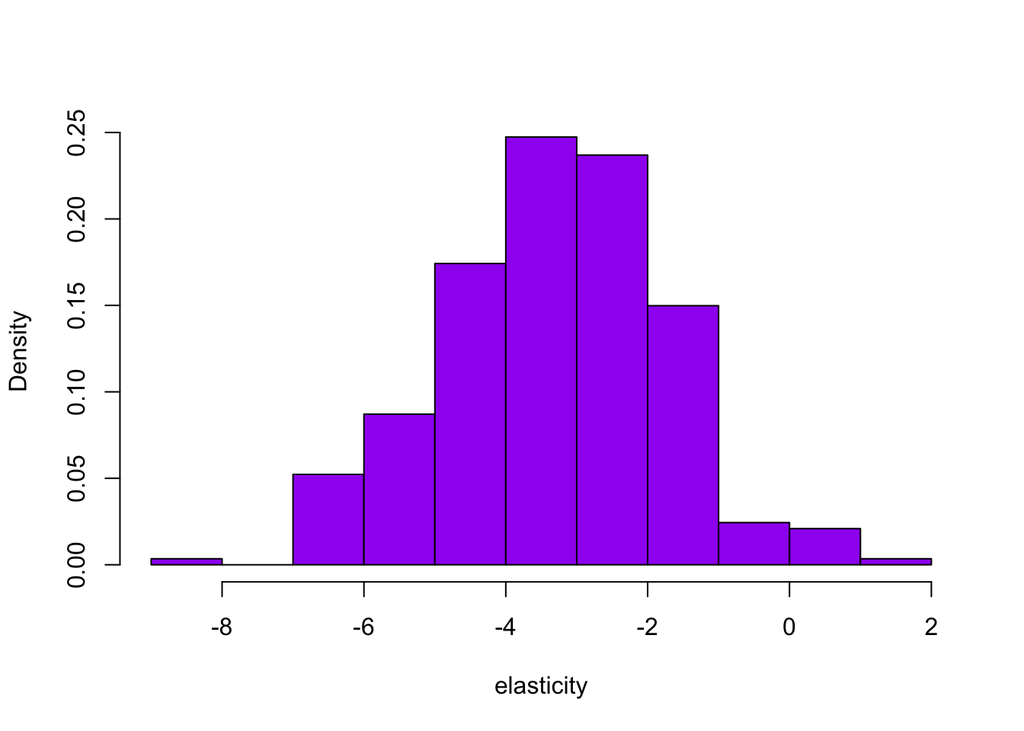

```r
hist(gamfull, main="", xlab="elasticity", col="purple", freq=FALSE)
```

This code builds a model to estimate how the interaction between item characteristics (including text descriptions) and prices affects sales, with the following steps: